# Week04_Friday slides

Sept 20, 2024

## Announcements

2. A04 due **Wednesday, 9/25/2024**

## Goals

1. Frames of reference intro
2. Work time A04

## What is the difference between how a robot perceives an object's position and how a GPS or an external observer would perceive the object's position?

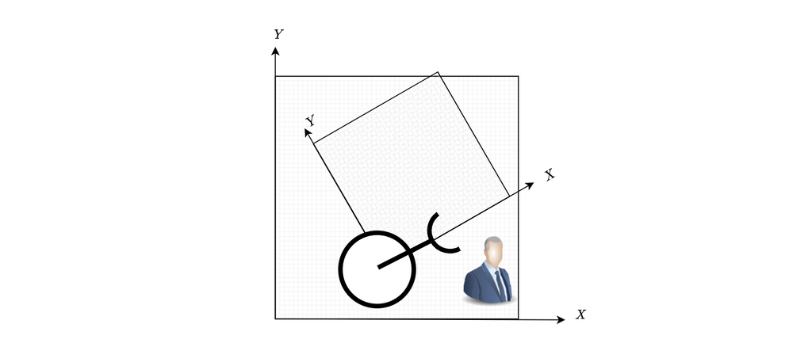

## What are "frames of reference?"

[figure not shown]

**Figure 1: Allocentric (A) and Egocentric (B) frames**

## Information about the an object's position (or velocity, or acceleration) can be expressed in *any* frame. How can we move from expressing in one frame to expressing in another?

- Translation representing the offset between coordinate frame origins
- Rotation of the point to match "new" unit vectors

## Nomenclature for vectors expressed in different frames of reference

## Nomenclature for vectors expressed in different frames of reference

$^A\vec{P} = \begin{bmatrix}^Ax_p & ^Ay_p & ^Az_p \end{bmatrix}^T$ represents the vector $\vec{P}$ expressed in the coordinates of frame "A."

$^B\vec{P} = \begin{bmatrix}^Bx_p & ^By_p & ^Bz_p \end{bmatrix}^T$ represents the vector $\vec{P}$ expressed in the coordinates of frame "B."

## Any position vector can also be written in terms of the frame's unit vectors

## Any position vector can also be written in terms of the frame's unit vectors

\begin{equation} \begin{aligned} ^A\vec{P} &=& ^Ax_p &\hat{x}_A &+& ^Ay_p &\hat{y}_A &+& ^Az_p &\hat{z}_A \\ &=& ^Ax_p &\begin{bmatrix} 1 \\ 0 \\ 0\end{bmatrix} &+& ^Ay_p &\begin{bmatrix} 0 \\ 1 \\ 0\end{bmatrix} &+& ^Az_p &\begin{bmatrix} 0 \\ 0 \\ 1\end{bmatrix} \end{aligned} \end{equation}

## Rotations: expressing one frame's unit vectors in terms of another frame's unit vectors

**Goal:** express the unit vector $\hat{x}_B$ in terms of frame A's unit vectors $\hat{x}_A,\hat{y}_A, \hat{z}_A$

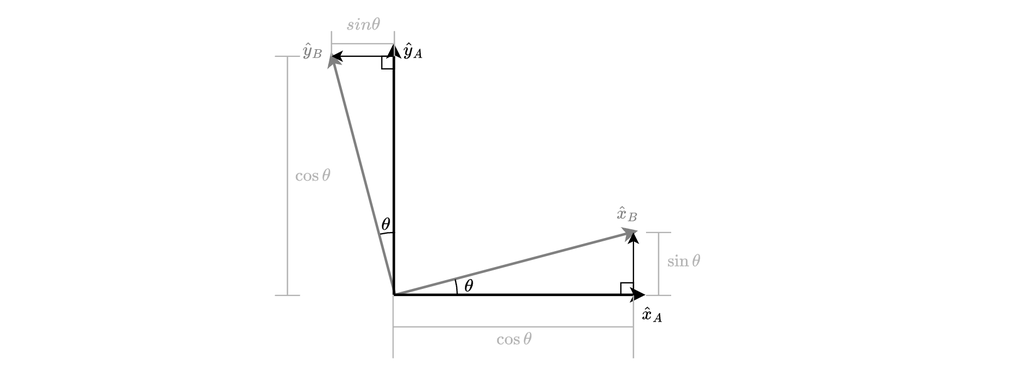

## Rotations: expressing one frame's unit vectors in terms of another frame's unit vectors

**Goal:** express the unit vector $\hat{x}_B$ in terms of frame A's unit vectors $\hat{x}_A,\hat{y}_A, \hat{z}_A$

For the $\hat{x}_B$ direction, \begin{equation} \hat{x}_B = \cos\theta \hat{x}_A + \sin\theta\hat{y}_A \end{equation}

Similarly, for the $\hat{y}_B$ direction, we can write:

\begin{equation} \hat{y}_B = -\sin\theta \hat{x}_A + \cos\theta\hat{y}_A \end{equation}

The $\hat{z}_A$ and $\hat{z}_B$ vectors are coincident and colinear, and in the same direction because our "2-D" or "planar" rotation was *about* the $\hat{z}$ axis. So, \begin{equation} \hat{z}_B = \hat{z}_A \end{equation}

## Rotations: expressing one frame's unit vectors in terms of another frame's unit vectors

**Goal:** express the unit vector $\hat{x}_B$ in terms of frame A's unit vectors $\hat{x}_A,\hat{y}_A, \hat{z}_A$

This transformation can actually be written compactly as a vector-matrix equation in 2D: \begin{equation} \underbrace{\begin{bmatrix}\hat{x}_B \\ \hat{y}_B \end{bmatrix}}_{\{B\}} = \underbrace{\begin{bmatrix} \cos\theta & \sin\theta \\ -\sin\theta & \cos\theta \end{bmatrix}}_{^B_AR_z(\theta)} \underbrace{\begin{bmatrix} \hat{x}_A \\ \hat{y}_A \\ \end{bmatrix}}_{\{A\}} \end{equation}

Or, in 3D, we merely need to include a row for the $z$ axis of each frame, resulting in an extra row and column in the rotation matrix.

\begin{equation} \underbrace{\begin{bmatrix}\hat{x}_B \\ \hat{y}_B \\ \hat{z}_B \end{bmatrix}}_{\{B\}} = \underbrace{\begin{bmatrix} \cos\theta & \sin\theta & 0 \\ -\sin\theta & \cos\theta & 0 \\ 0 & 0 & 1 \end{bmatrix}}_{^B_AR_z(\theta)} \underbrace{\begin{bmatrix} \hat{x}_A \\ \hat{y}_A \\ \hat{z}_A\end{bmatrix}}_{\{A\}} \end{equation}

Notice that here, we are denoting the vector of directions for frame $A$ as $\{A\}$, and likewise with frame $B$'s directions, $\{B\}$.

## Rotation Matrices

If we write: \begin{equation} \underbrace{\begin{bmatrix}\hat{x}_B \\ \hat{y}_B \end{bmatrix}}_{\{B\}} = \underbrace{\begin{bmatrix} \cos\theta & \sin\theta \\ -\sin\theta & \cos\theta \end{bmatrix}}_{^B_AR_z(\theta)} \underbrace{\begin{bmatrix} \hat{x}_A \\ \hat{y}_A \\ \end{bmatrix}}_{\{A\}} \end{equation}

We call $_A^BR_z(\theta)$ a *rotation matrix*. We read its preceding subscript and superscript as transforming *from* the unit vectors in frame $A$ *to* the unit vectors of frame $B$ (just how we described it while doing simple vector addition). We read its trailing subscript as a rotation *about* the $z$-axis of the "from" frame, which in this case was $A$. Finally, we read that this rotation matrix is a function of the rotation angle, which in this case we called $\theta$.

## Inverse Rotations

We can also write the unit vectors for coordinate system $A$ (transform *into* A's perspective) in terms of the unit vectors of coordinate system $B$, shown graphically below.

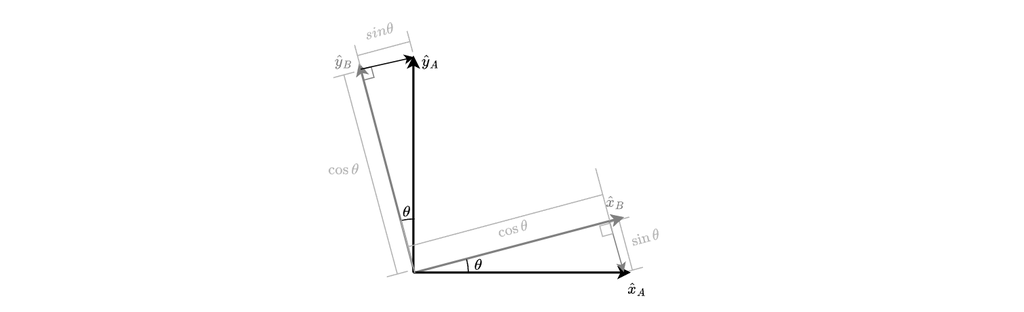

## Inverse Rotations

\begin{equation} \underbrace{\begin{bmatrix}\hat{x}_A \\ \hat{y}_A \end{bmatrix}}_{\{A\}} = \underbrace{\begin{bmatrix} \cos\theta & -\sin\theta \\ \sin\theta & \cos\theta \end{bmatrix}}_{^A_BR_z(\theta)} \underbrace{\begin{bmatrix} \hat{x}_B \\ \hat{y}_B \end{bmatrix}}_{\{B\}} \end{equation}

What you'll notice is that mathematically, this Rotation matrix $^B_AR_z(\theta)$ is the *inverse* of $^A_BR_z(\theta)$. This is because If I wrote:

\begin{equation} \{B\} = _A^BR_z(\theta)\{A\} \end{equation}

and I wanted to solve for $\{A\}$ in equation 9 instead, I could simply pre-multiply both sides of the equation by the inverse of my rotation matrix $R$:

\begin{equation} \begin{aligned} _A^B R_z( \theta)^{-1}\{B\} &= \underbrace{_A^B R_z( \theta )^{-1}\cdot _A^BR_z(\theta)}_{\mathbb{I}_{3x3}}\{A\} \\ _A^BR_z(\theta)^{-1}\{B\} &= \{A\} \\ _B^AR_z(\theta)\{B\}&=\{A\} \end{aligned} \end{equation}

## Inverse Rotations

You can confirm that the inverses work out for our two examples above on your own using the formula for the [inverse](https://www.cuemath.com/algebra/inverse-of-3x3-matrix/) of a 3x3 matrix for the 3D case, or using the [2x2 inverse](https://www.cuemath.com/algebra/inverse-of-2x2-matrix/) for the 2D case.

But it gets better. Because each of the columns of a matrix expresses a unit vector, of a few key properties of rotation matrices, mainly that a rotation matrix $R$ forms an "orthonormal basis," the inverse of a rotation matrix is *equivalent to its transpose!*. In other words, we don't have to do anything wild or complicated to find an inverse rotation matrix. We can simply write: \begin{equation} ^A_BR(\theta)=^B_AR(\theta)^T \end{equation} That's right. Inverse rotation matrices are simply *transposes* of one another. Pretty cool! Pretty easy!

## Representing Rotations in Python (in 2D)

Representing Rotations in the Python language is relatively easy with the numpy library. See the example function below, which creates a 2D rotation matrix using a single angle $\theta$. **Note that this function is designed to produce $^B_A R$, which transforms *into* frame $B$ from frame $A$.**

```
import numpy as np
def create2DRotationAB(theta):
    """ Create a 2D rotation matrix AB_R (R from A to B ) to express the unit vectors of coordinate system B
        in terms of the unit vectors of coordinate system B.
        If you wish to do the opposite (transform unit vectors of A into B's coordinates), you can invert/transpose this matrix.
        The angle you feed this function should be in RADIANS.

        note that the matrix equation here is [xhatb,yhatb]' = R*[xhata,yhata]' where ' represents transpose.
    """
    return np.array([[np.cos(theta),np.sin(theta)],[-np.sin(theta),np.cos(theta)]])
```

## In-Class Example: Transforming Robot Velocity from local to global coordinates

Write a Python script to create a 0.2-radian rotation matrix in 2D. Imagine that our robot knows that its "yaw" angle (angle about the gravitational axis) with respect to a global XY frame is 0.2 radians, for example. If the robot knows its *local* velocity (for example, 2 m/s forward in its local x-direction), we can use this transformation to determine the robot's *global* velocity (east as X, and Y as north, for example). We need to write:

\begin{equation} ^A\vec{v}=_B^AR ^B\vec{v} \end{equation}

Note that because the function is written as a transform from frame A to frame B, which means taking a vector originally expressed in A's unit vectors and then transforming them to be expressed in B's unit vectors, we actually need the *inverse* of the rotation the function gives us, since $^B\vec{v}$, the velocity we want to transform, is in B's unit vectors already, and needs to be expressed in terms of A's unit vectors.

```
import numpy as np
def create2DRotationAB(theta):
    """ Create a 2D rotation matrix AB_R (R from A to B ) to express the unit vectors of coordinate system B
        in terms of the unit vectors of coordinate system B.
        If you wish to do the opposite (transform unit vectors of A into B's coordinates), you can invert/transpose this matrix.
        The angle you feed this function should be in RADIANS.

        note that the matrix equation here is [xhatb,yhatb]' = R*[xhata,yhata]' where ' represents transpose.
    """
    return np.array([[np.cos(theta),np.sin(theta)],[-np.sin(theta),np.cos(theta)]])
```

```
theta = 0.2 #angle about which we will rotate in a plane
AB_R = create2DRotationAB(theta) #creates expression in A's frame of B's unit vectors (transforms from A to B)
BA_R = AB_R.T #transpose of the rotation creates an expression in B's frame of A's unit vectors (transforms from B to A)
print(BA_R)
```

```
[[ 0.98006658 -0.19866933]
 [ 0.19866933  0.98006658]]
```